# Rethinking Chapter 2

Pablo Bello

9/23/2022

```r
library(tidyverse)
library(ggpubr)
library(patchwork)
```

**As you will see, throughout the exercises I mix base R and tidyverse. This is not just a lazy choice. I actually think that writing in base R is better to grasp the logic of algorithms, statistical methods, or simulations. It is much worse, however, for plotting, so whenever I plot something I just crunch vectors into a tibble and make a ggplot.**

### 2E1

Both (2) and (4) are true. $P(rain|Monday)$ and
$$\frac{P(rain, Monday)}{P(Monday)} = \frac{P(rain | Monday) * P(Monday)}{P(Monday)} = P(rain | Monday)$$

### 2E2

The answer is (3) the probability that it is Monday, given that it is raining.

### 2E3

Both (1) and (4) are true.
$$P(Monday|rain)$$
and
$$\frac{P(rain|Monday) P(Monday)} {P(rain)} = P(Monday|rain)$$

### 2E4

A frequentist interpretation of “the probability of water is 0.7” would be that if we repeat our trial an infinite amount of times, the expected proportion of waters will be .7. I’m not too sure about this but a Bayesian interpretation would be that given our data the best guess as to what is the real water/land composition of the earth is 70% water.

### 2M1

```r
###--- Grid  Approximation Function

grid_approx <- function(W, L, grid_n, plot = TRUE, prior_f = NULL) {
  # Define Grid
  p_grid <- seq(from=0, to=1, length.out = grid_n)

  # Define Prior
  prior <- rep(1, grid_n)

  # If I don't want a uniform then take them as an input
  if(is.null(prior_f) == FALSE) {
    prior <- ifelse(p_grid < 0.5, 0, 1)
  }

  # Compute Likelihood at each value ingrid
  likelihood <- dbinom(W, size= W + L, prob = p_grid)

  # Compute Product of Likelihood and Prior
  unstd_posterior <- likelihood * prior

  # Standardize The posterior, so it sums to 1
  posterior <- unstd_posterior / sum(unstd_posterior)

  # Put params and posterior together and return it
  tbl <- tibble(p_water = p_grid, posterior_probability = posterior)

  if(plot == TRUE) {
  p <- tbl |>
    ggplot(aes(p_water, posterior_probability)) +
    geom_line() +
    geom_point() +
    labs(x = "Probability of Water",
         y = "Posterior Probability",
         title = paste0("W = ",W,", L =", L)) +
    theme_pubr(border = TRUE) +
    scale_x_continuous(n.breaks = 3)


  return(p)
  }

  else{
    return(tbl)
  }
}
```

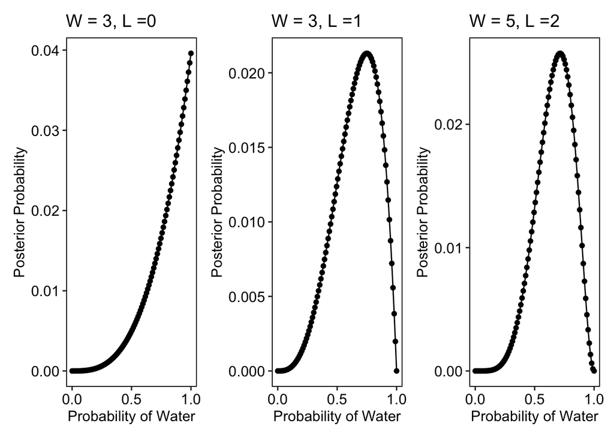

```r
p1 <- grid_approx(3,0,100,TRUE)
p2 <- grid_approx(3,1,100,TRUE)
p3 <- grid_approx(5,2,100,TRUE)

p1 + p2 + p3
```

### 2M2

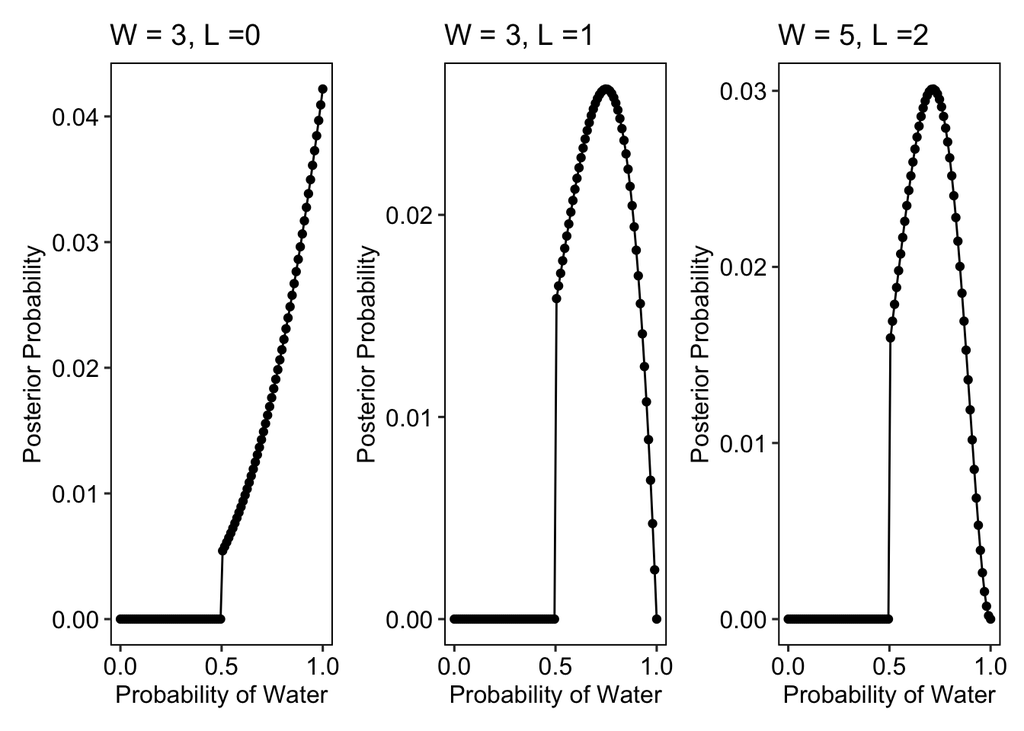

```r
###--- Now with the step function for priors
p1 <- grid_approx(3,0,100,TRUE,prior_f = "step")
p2 <- grid_approx(3,1,100,TRUE,prior_f = "step")
p3 <- grid_approx(5,2,100,TRUE,prior_f = "step")

p1 + p2 + p3
```

### 2M3

$P(Earth|land) = \frac{P(land|Earth) \cdot P(Earth)}{P(land)} = \frac{.3 \times .5}{.3 \times .5 + .5} \approx .23$

### 2M4

There are two ways in which the other side can be black, if the card pulled is the B/B card. There is one way in which it can be black, if the card is the B/W card. So P = 2/3

### 2M5

In this case there would be 4 options for a second black side (the 2 B/B cards) and 1 for a white side , so 4/5

### 2M6

We can just act as if there were 2 W/B cards, so now again there are 2 ways for the second side to be black (the B/B cards), but 2 for it to be white (the two B/W cards). So the probability is 2/4.

### 2M7

First count how many ways to observe the sequence. To see a first B side we draw the B/B card that’s 2, then from the other 2 cards there are 3 ways to produce a W side, so that makes 2X3 = 6 ways. If the first card is the B/W that’s 1 way to get a B, and then there are 2 ways to get a W from the other cards (from the W/W card), so that’s 2X1 = 2 ways. So the probability of the first card being B/B is 6/(6 + 2) = .75

### 2H1

$P(second.twins | first.twins) = \frac{P(first.twins,second.twins)}{P(twins)}$

$P(twins) = P(A) * P(twins | A) + P(B) * P(twins | B) = .5*.1 + .5*.2 = .15$

$P(twins_1,twins_2) = P(twins | A)^2 \cdot P(A) + P(twins |B)^2 \cdot P(B) = .1^2 \times 1/2 + .2^2 \times 1/2= .025$

$P(twins_2 | twins_1) = \frac{P(twins_1,twins_2)}{P(twins)} = \frac{.025}{.15} \approx .17$

### 2H2

$P(A|twins_1) = \frac{P(twins|A) \cdot P(A)}{P(twins)} = \frac{.1\times.5}{.15} = 1/3$

### 2H3

Based on the last problem, $P(A|twins_1) = 1/3$ which we can use as a prior in this new problem.So $P(A) = 1/3$. Then:

$P(A | singleton) = \frac{P(singleton|A) \cdot P(A)}{P(singleton)}$

$P(singleton) = P(singleton | A) \cdot P(A) + P(singleton | B) \cdot P(B) = .9*1/3 + .8*2/3 \approx .83$

$P(A | singleton) = \frac{P(singleton|A) \cdot P(A)}{P(singleton)} = \frac{.9 \times 1/3}{.83} \approx .36$

### 2H4

I assume here that the test always comes back with an answer and that it is either A or B (i.e. $P(test_A) + P(test_B) = 1$)

$P(A | test_A) = \frac{P(test_A | A) \cdot P(A)}{P(test_A)} = \frac{.8 * 1/2} {.8 * 1/2 + (1 - .65)* 1/2} \approx .695$

To update the previous problem with our new information I just start with $P(A |singleton) = .36$ as a prior.

$P(A | test_A) = \frac{P(test_A | A) \cdot P(A)}{P(test_A)} = \frac{.8 * .36} {.8 * .36 + (1 - .65)* (1 - .36)} = 0.5625$